# Mortality Surveillance

October 2019

## Background

6 days work by 1 analyst

Only completed 3x in a year

9 clinical databases on 2 systems (Rio and S1)

2 non clinical datasets (incidents and Coroners Verdict)

## How?…

Excel copying, checking, pasting and ultimately: VLOOKUPS

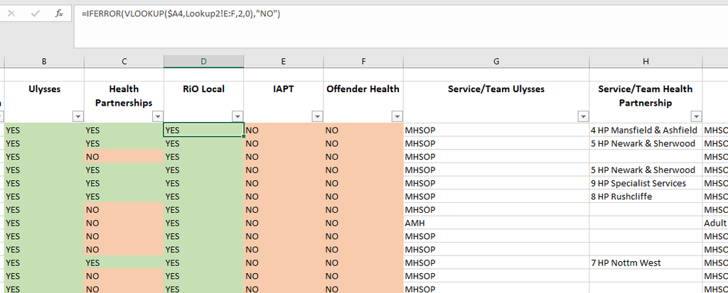

## But…

What about patients who access multiple services?

Do deaths by ethnicity and gender reflect the same Public Health patterns?

## SQL solution v1.0

First attempt is wide data.

| PatientID | SystmOne | Rio instance1 | Rio instance2 | Rio instance3 |
| --- | --- | --- | --- | --- |
| Patient A | 1 | 1 | 0 | 0 |

## Wide and long form data

| id | Ward | Referrals |
| --- | --- | --- |
| Patient A | Ward 1 | Team A |
| Patient B | Ward 2 | Team B |

Long table (in R uses gather function in dplyr)

| id | Activity | Detail |
| --- | --- | --- |
| Patient A | Ward | Ward 1 |
| Patient A | Referrals | Team A |
| Patient B | Ward | Ward 2 |
| Patient B | Referrals | Team B |

## Further reading

*Journal of Statistical Software*, Tidy Data, Hadley Wickham

https://vita.had.co.nz/papers/tidy-data.pdf

[figure not shown]

## SQL solution v2.0

| PatientID | System | DOB | DOD |
| --- | --- | --- | --- |
| Patient A | SystmOne | 01/01/1900 | 02/02/1910 |
| Patient A | Rio instance1 |  | 02/02/2010 |
| Patient A | Rio instance2 | 01/01/2000 |  |

## Data warehouse rights

New server = BORIS (no rights to update/delete/drop table)

Old server = Temp_tables (full rights)

```sql
-- In BORIS newServer

INSERT OPENQUERY([oldServer],'
SELECT *
  FROM [oldServer].[ZT].[PatientIndex]')
SELECT *
 FROM #tmp
```

## SQL solution v2.1

Originally for all patients:

- 1 script to build
- OPENQUERY to OldServer
- 1 script to amend (merged DOD, DOB, Ethnicity, Gender…)

## SQL solution v2.2

Now:

- 1 script to build and amend
- OPENQUERY only those who have died since 2015

## SQL solution v2.3

Now:

- 1 script to build an amend
- OPENQUERY only those who have died since 2015
- AND who are not already in the existing table

## Things I learned

- Back up tables before running any code that makes changes
- Add an id to any table you create
- Write notes to your future self
- Number the chunks of SQL code
- I probably haven't finished at v2.3 …

## Now for the data feed to R…

That's the data created

## Data feed before analysis

Back to wide data!

| PatientID | SystmOIne | Rio Instance1 | Rio Instance2 |
| --- | --- | --- | --- |
| Patient A | 1 | 1 | 0 |
| Patient B | 0 | 1 | 0 |
| Patient C | 1 | 1 | 0 |

## SQL MAX(CASE….)

```sql
SELECT
p.MergedID
,p.DateOfBirth_skMerge
,SystmOne = MAX(CASE WHEN p.System = 'S1' THEN 1 ELSE 0 END)
,RioLOCAL = MAX(CASE WHEN p.System = 'LOCAL' THEN 1 ELSE 0 END)
FROM #pat                           AS p
GROUP BY  p.MergedID
,p.DateOfBirth_skMerge
```

## Output

[output not shown]

## Then back to long data!

| MergedID | System | Description | Active | LoadedDate_sk |
| --- | --- | --- | --- | --- |
| 123 | S1 | NA | 1 | 20190513 |
| 123 | Rio Referrals | AMH | 0 | 20190513 |
| 123 | Rio Inpatients | Ward A | 0 | 20190513 |
| 126 | S1 | NA | 1 | 20190513 |

## Now to the analysis in R…

This was presented originally to R-Ladies